# Topic Modeling Analysis

Author

“Kristin Lloyd”

```r
options(repos = c(CRAN = "https://cran.rstudio.com"))
install.packages("tidyverse")
library(tidyverse)
install.packages("wordcloud")
library(wordcloud)
library(ggplot2)
library(dplyr)
library(tidyr)
library(stringr)
```

## Senators

Let’s load the dataset and analyze the topics generated by the model. This will provide valuable insights into how senators discuss climate change, highlighting key areas of focus.

```r
df <- read.csv("../Data/processed-data/Senators_sentiment3.csv")
head(df)
```

```
  first      last party state ideology_score  region year source likes shares
1  Alex   Padilla     D    CA         -0.375 Midwest 2023      X   104     28
2  Alex   Padilla     D    CA         -0.375 Midwest 2024      X    68     33
3  Alex   Padilla     D    CA         -0.375 Midwest 2023      X    92     20
4   Amy Klobuchar     D    MN         -0.283 Midwest 2023      X    18      9
5   Amy Klobuchar     D    MN         -0.283 Midwest 2022      X  1600    269
6   Amy Klobuchar     D    MN         -0.283 Midwest 2021      X   510     96
  views
1  4756
2  8176
3  6516
4  3985
5
6
                                                                                                                                                                            message
```

[output cut: 27 more lines]

Let’s explore the most frequently used words in the senators’ sentiments by creating a bar chart to visualize the distribution.

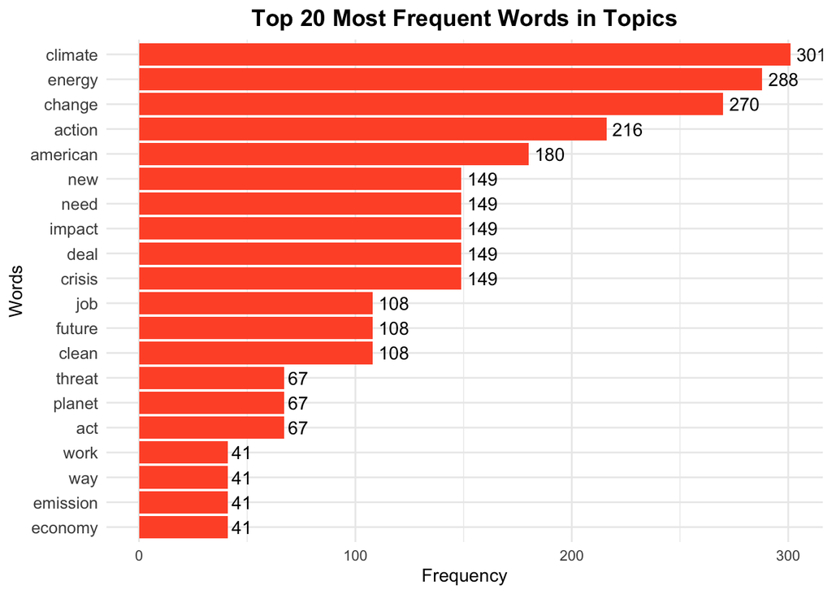

```r
word_frequencies <- df %>%
  mutate(words = strsplit(as.character(dominant_topic), ",|\\s+")) %>%
  unnest(words) %>%
  filter(words != "") %>%
  group_by(words) %>%
  summarise(
    frequency = n(),
    .groups = 'drop'
  ) %>%
  arrange(desc(frequency)) %>%
  head(20)

ggplot(word_frequencies, aes(x = reorder(words, frequency), y = frequency)) +
  geom_bar(stat = "identity", fill = "#FF5733") +
  coord_flip() +
  labs(
    title = "Top 20 Most Frequent Words in Topics",
    x = "Words",
    y = "Frequency"
  ) +
  theme_minimal() +
  theme(
    plot.title = element_text(hjust = 0.5, size = 14, face = "bold"),
    axis.text.y = element_text(size = 10)
  ) +
  geom_text(aes(label = frequency), hjust = -0.2)
```

```r
cat("\nTop 20 Most Frequent Words:\n")
```

```
Top 20 Most Frequent Words:
```

```r
print(word_frequencies, n = 20)
```

```
# A tibble: 20 × 2
   words    frequency
   <chr>        <int>
 1 climate        301
 2 energy         288
 3 change         270
 4 action         216
 5 american       180
 6 crisis         149
 7 deal           149
 8 impact         149
 9 need           149
10 new            149
11 clean          108
12 future         108
13 job            108
14 act             67
15 planet          67
16 threat          67
17 economy         41
18 emission        41
19 way             41
20 work            41
```

These words emphasize the central focus on climate-related issues, particularly around energy transitions and addressing climate change. Words like “action,” “impact,” and “crisis” highlight the urgency associated with these discussions. Let’s create a word cloud for easier readbility.

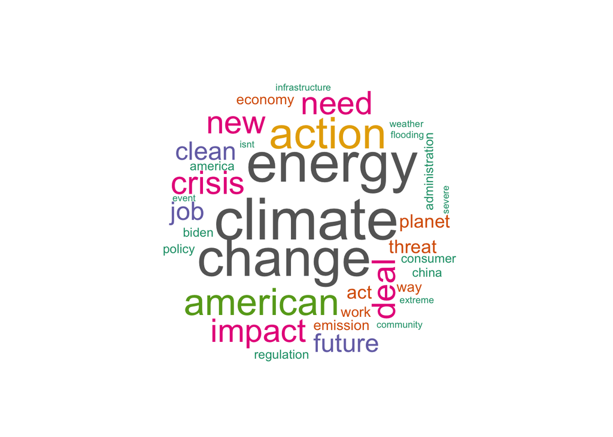

```r
word_frequencies <- df %>%
  mutate(words = strsplit(as.character(dominant_topic), ",|\\s+")) %>%
  unnest(words) %>%
  filter(words != "") %>%
  group_by(words) %>%
  summarise(
    frequency = n(),
    .groups = 'drop'
  ) %>%
  arrange(desc(frequency))

wordcloud(
  words = word_frequencies$words,
  freq = word_frequencies$frequency,
  min.freq = 2,
  max.words = 100,
  random.order = FALSE,
  colors = brewer.pal(8, "Dark2")
)
```

Next, let’s examine the most frequently occurring words by Democratic and Republican senators.

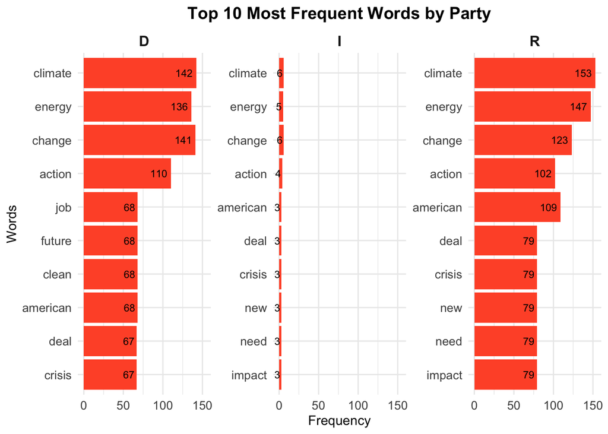

```r
word_party_frequencies <- df %>%
  mutate(words = strsplit(as.character(dominant_topic), ",|\\s+")) %>%
  unnest(words) %>%
  filter(words != "", !words %in% c("and", "the")) %>%
  group_by(party, words) %>%
  summarise(
    frequency = n(),
    .groups = 'drop'
  ) %>%
  arrange(party, desc(frequency))

top_party_words <- word_party_frequencies %>%
  group_by(party) %>%
  slice_head(n = 10) %>%
  ungroup()

ggplot(top_party_words, aes(x = reorder(words, frequency),
                            y = frequency)) +
  geom_bar(stat = "identity", fill = "#FF5733") +
  facet_wrap(~party, scales = "free_y") +
  coord_flip() +
  geom_text(aes(label = frequency), hjust = 1.2, color = "black", size = 3) + # Text inside the bars
  labs(
    title = "Top 10 Most Frequent Words by Party",
    x = "Words",
    y = "Frequency"
  ) +
  theme_minimal() +
  theme(
    plot.title = element_text(hjust = 0.5, size = 14, face = "bold"),
    axis.text = element_text(size = 10),
    strip.text = element_text(size = 12, face = "bold")
  )
```

While the differences are not vast, one notable observation is that the word “future” did not appear in the top ten for republican senators, despite its critical relevance to climate change. Similarly, republicans did not include “jobs” in their top ten words, which is surprising given its significance in discussions about climate policies and their impact on employment. Both parties, however, share a focus on “climate,” “change,” “action,” and “energy” as their top four words. Republicans frequently used the word “American,” suggesting a strong emphasis on how climate change or related policies affect Americans directly—either due to the consequences of climate change or the measures implemented to combat it. Now, let’s explore word frequencies by region.

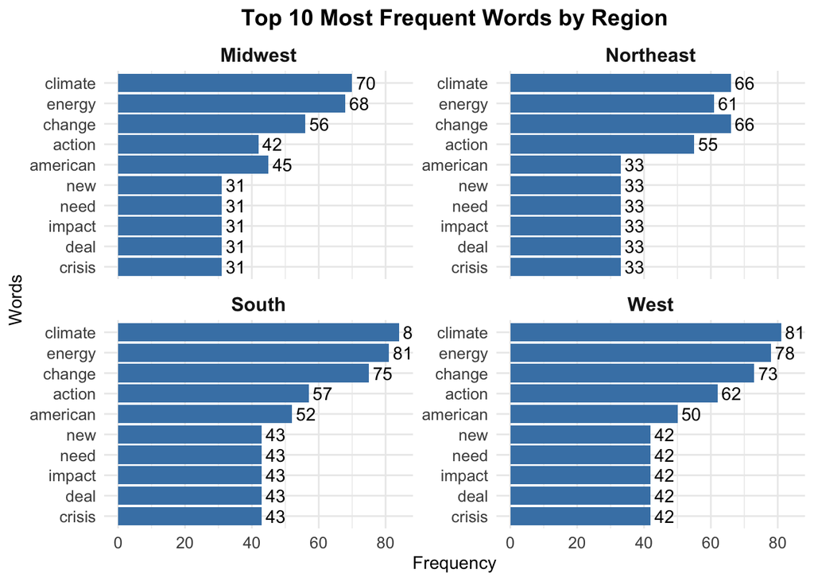

```r
word_region_frequencies <- df %>%
  mutate(words = strsplit(as.character(dominant_topic), ",|\\s+")) %>%
  unnest(words) %>%
  filter(words != "") %>%
  filter(words != "and") %>%
  group_by(region, words) %>%
  summarise(
    frequency = n(),
    .groups = 'drop'
  ) %>%
  arrange(region, desc(frequency))

top_region_words <- word_region_frequencies %>%
  group_by(region) %>%
  slice_head(n = 10) %>%
  ungroup()

ggplot(top_region_words, aes(x = reorder(words, frequency),
                           y = frequency)) +
  geom_bar(stat = "identity", fill = "steelblue") +
  facet_wrap(~region, scales = "free_y") +
  coord_flip() +
  labs(
    title = "Top 10 Most Frequent Words by Region",
    x = "Words",
    y = "Frequency"
  ) +
  theme_minimal() +
  theme(
    plot.title = element_text(hjust = 0.5, size = 14, face = "bold"),
    axis.text = element_text(size = 10),
    strip.text = element_text(size = 12, face = "bold")
  ) +
  geom_text(aes(label = frequency), hjust = -0.2)
```

There is no significant difference between the different regions.

## President

```r
df_president <- read.csv("../Data/processed-data/President_sentiment3.csv")
head(df)
```

```
  first      last party state ideology_score  region year source likes shares
1  Alex   Padilla     D    CA         -0.375 Midwest 2023      X   104     28
2  Alex   Padilla     D    CA         -0.375 Midwest 2024      X    68     33
3  Alex   Padilla     D    CA         -0.375 Midwest 2023      X    92     20
4   Amy Klobuchar     D    MN         -0.283 Midwest 2023      X    18      9
5   Amy Klobuchar     D    MN         -0.283 Midwest 2022      X  1600    269
6   Amy Klobuchar     D    MN         -0.283 Midwest 2021      X   510     96
  views
1  4756
2  8176
3  6516
4  3985
5
6
                                                                                                                                                                            message
```

[output cut: 27 more lines]

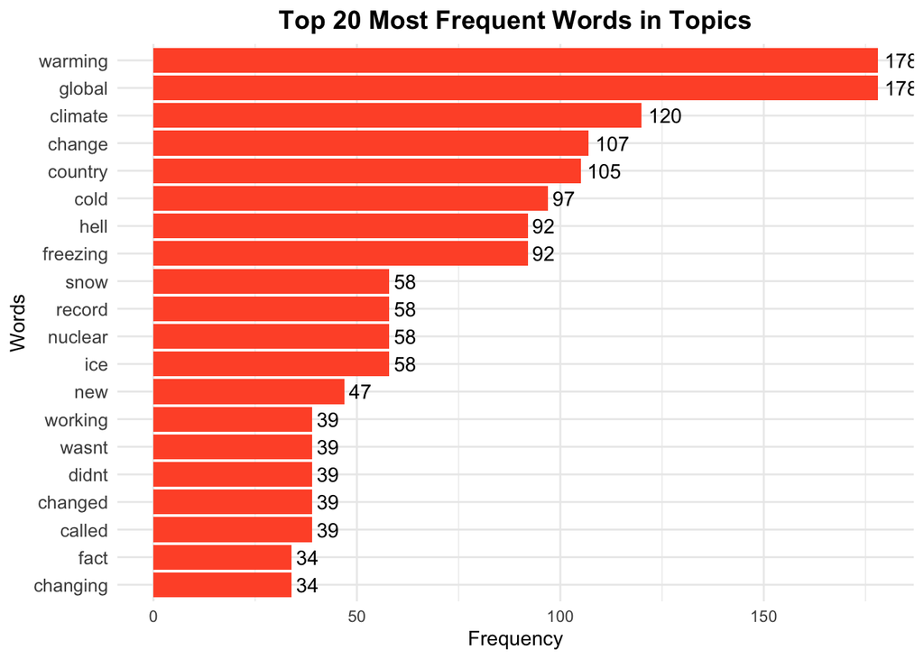

```r
word_frequencies <- df_president %>%
  mutate(words = strsplit(as.character(dominant_topic), ",|\\s+")) %>%
  unnest(words) %>%
  filter(words != "") %>%
  group_by(words) %>%
  summarise(
    frequency = n(),
    .groups = 'drop'
  ) %>%
  arrange(desc(frequency)) %>%
  head(20)

ggplot(word_frequencies, aes(x = reorder(words, frequency), y = frequency)) +
  geom_bar(stat = "identity", fill = "#FF5733") +
  coord_flip() +
  labs(
    title = "Top 20 Most Frequent Words in Topics",
    x = "Words",
    y = "Frequency"
  ) +
  theme_minimal() +
  theme(
    plot.title = element_text(hjust = 0.5, size = 14, face = "bold"),
    axis.text.y = element_text(size = 10)
  ) +
  geom_text(aes(label = frequency), hjust = -0.2)
```

```r
cat("\nTop 20 Most Frequent Words:\n")
```

```
Top 20 Most Frequent Words:
```

```r
print(word_frequencies, n = 20)
```

```
# A tibble: 20 × 2
   words    frequency
   <chr>        <int>
 1 global         178
 2 warming        178
 3 climate        120
 4 change         107
 5 country        105
 6 cold            97
 7 freezing        92
 8 hell            92
 9 ice             58
10 nuclear         58
11 record          58
12 snow            58
13 new             47
14 called          39
15 changed         39
16 didnt           39
17 wasnt           39
18 working         39
19 changing        34
20 fact            34
```

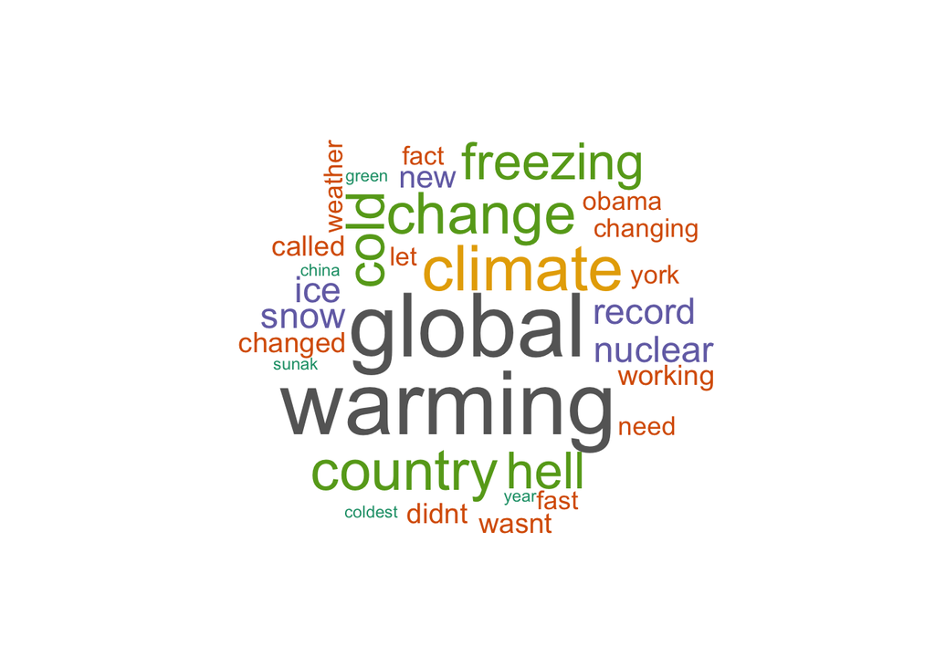

```r
word_frequencies <- df_president %>%
  mutate(words = strsplit(as.character(dominant_topic), ",|\\s+")) %>%
  unnest(words) %>%
  filter(words != "") %>%
  group_by(words) %>%
  summarise(
    frequency = n(),
    .groups = 'drop'
  ) %>%
  arrange(desc(frequency))

wordcloud(
  words = word_frequencies$words,
  freq = word_frequencies$frequency,
  min.freq = 2,
  max.words = 100,
  random.order = FALSE,
  colors = brewer.pal(8, "Dark2")
)
```

The President’s sentiment differs significantly from that of the senators. While he frequently mentions climate change and global warming, four of his top words—“cold,” “freezing,” “snow,” and “ice”—highlight his tendency to joke about cold weather as a counterpoint to global warming. As President of the United States, one might expect a more serious focus on climate-related topics. However, it is important to note that his sentiment analysis spans back to 2013, whereas the senators sentiments are all recent.